# Exemplo: Contagem de bovinos

Alcinei Mistico Azevedo (ICA-UFMG)

2023-12-14

# Introdução

Obrigado por utilizar o pacote `ExpImage`. Este pacote foi desenvolvido a fim de facilitar o uso da analise de imagens na obtenção de várias informações sobre os objetos que elas contém. Para a utilização do pacote é indispensável a instalação do pacote `EBImage`. Geralmente, este pacote pode ser instalado ao executar os seguintes comandos:

`if (!requireNamespace("BiocManager", quietly = TRUE))`

`install.packages("BiocManager")`

`BiocManager::install("EBImage")`

Porém se houver problemas na instalação sugerimos que consulte mais opções de instalação no site: https://bioconductor.org/packages/release/bioc/html/EBImage.html

Para instalar o pacote ´ExpImage´ basta utilizar o seguinte comando:

`install.packages("ExpImage")`

Convidamos a todos os usuários do ExpImage que venha conhecer nossos materiais didáticos sobre este e outros pacotes nos seguintes links:

https://www.youtube.com/channel/UCDGyvLCJnv9RtTY1YMBMVNQ

https://www.expstat.com/

# Abrindo as imagens no R

## Ativação dos pacotes

Após a instalação dos pacotes é necessário fazer sua ativação

```r
 library(EBImage)
library(ExpImage)
```

## Abrindo as imagens.

Para abrir as imagens pode-se inicialmente indicar a pasta de trabalho onde a imagem se encontra com a função `setwd`. E, posteriormente, abrir a imagem com a função `read_image`.

Neste caso, poderiam ser utilizados comandos como esses:

`#Apagar memoria do R`

`remove(list=ls())`

`#Indicar a pasta de trabalho`

`setwd("D:/Backup Pendrive/")`

`im=read_image("Imagem.jpeg",plot=TRUE)`

Neste exemplo utilizaremos uma imagem contida no banco de dados do pacote.

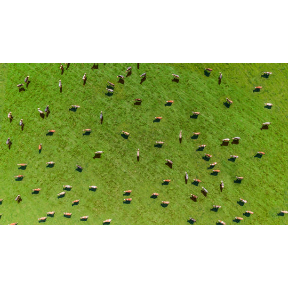

```r
# Obtendo o endereço da imagem de exemplo
end=example_image(11)
im=read_image(end,plot=TRUE)
```

Vamos verificar qual é o melhor índice para fazer a segmentação.

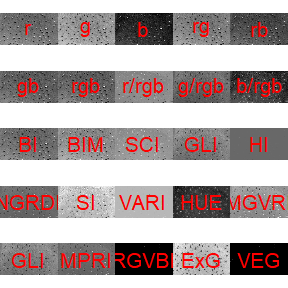

```r
plot_indexes(im,NumberCores=2)
```

O Índice ExG é uma ótima opção para a segmentação, pois os bovinos se destacaram bastante em relação ao solo.

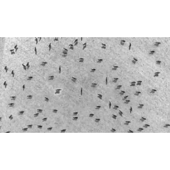

```r
#Criando o objeto com o índice
im2=gray_scale(im,method = "ExG",plot=T)
```

Agora podemos fazer a segmentação. Para isso utilizaremos o algorítimo de otsu a fim de selecionar os pixels de menores valores (foregrounds)

```r
max(c(im2@.Data))
```

```
#> [1] 1
```

```
#> [1] "The threshold by Otsu method is (O valor do limiar pelo metodo otsu e): 0.5605"
```

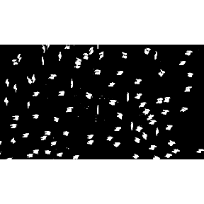

```r
im3=segmentation(im2,treshold = "otsu",selectHigher = FALSE,plot=TRUE)
```

A partir dessa imagem segmentada podemos contar o número de objetos.

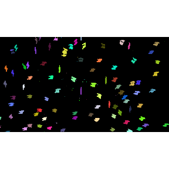

```r
im4=measure_image(im3)
```

```r
#Numero de objetos
im4$ObjectNumber
```

```
#> [1] 149
```

```r
#Tamanho em pixels de cada objeto
im4$measures[,3]
```

```
#>   1   2   3   4   5   6   7   8   9  10  11  12  13  14  15  16  17  18  19  20
#> 111   6  48 113   4   3  45 194   1 206   1   1   1 193 178 123 152 186 205 148
#>  21  22  23  24  25  26  27  28  29  30  31  32  33  34  35  36  37  38  39  40
#> 117 373   1  66   1   1  84   1   1 171   2   1 206 187 172 161   2 166 196 152
#>  41  42  43  44  45  46  47  48  49  50  51  52  53  54  55  56  57  58  59  60
#>   1 140 209 137 171 137   2 208   3   2 198 174 232 139 209   2   1   1   4   4
#>  61  62  63  64  65  66  67  68  69  70  71  72  73  74  75  76  77  78  79  80
#> 213 157   3 231   2   8   2   3   1   1 234 102   5 196   1 128   1   2 212 184
#>  81  82  83  84  85  86  87  88  89  90  91  92  93  94  95  96  97  98  99 100
#>   1   6 232   1   1 193   1 211   1 175 186   1 177   1   5 160   1   1   1   4
#> 101 102 103 104 105 106 107 108 109 110 111 112 113 114 115 116 117 118 119 120
#>   1 191   8 139 181 203 214   1 177 135 180 167 192 167 166 163   1   1 166 187
#> 121 122 123 124 125 126 127 128 129 130 131 132 133 134 135 136 137 138 139 140
#> 138   3   1 173 206  30 146 193 198   5   8   2 174 162 164 163   2   4   1 152
#> 141 142 143 144 145 146 147 148 149
#>   5 176 144 163 163 170  87   2   1
```

Como pode-se observar, o número de objetos é muito superior ao número de animais. Isso é uma consequência do ruido. Podemos ver na terceira coluna da tabela anterior o número de pixels de cada objeto. Os menores valores de área são os ruidos. Logo, podemos selecionar um valor a partir do qua não consideraremos ruídos. Ao olhar o conjunto de dados podemos ver que um ruído de 50 pode permitir selecionar apenas os animais.

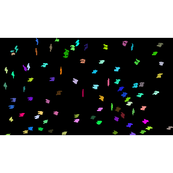

```r
im4=measure_image(im3,noise=50)
```

```r
im4$measures[,1:3]
```

```
#>          x       y area
#> 1  131.081  11.820  111
#> 2  201.814   7.938  113
#> 3  273.619  17.974  194
#> 4  441.083  18.607  206
#> 5  565.819  24.155  193
#> 6  303.815  31.281  178
#> 7  467.073  32.065  123
#> 8  179.316  34.099  152
#> 9  373.016  32.253  186
#> 10 257.073  34.532  205
#> 11  57.426  37.966  148
#> 12 128.017  48.709  117
#> 13 233.799  55.477  373
#> 14  42.364  46.924   66
```

[output cut: 68 more lines]

```r
#Numero de objetos
im4$ObjectNumber
```

```
#> [1] 82
```

Para conferir se este número de animais está correto podemos marcar na imagem as coordenadas de cada animal, considerando só dados das duas primeiras colunas do conjunto de dados.

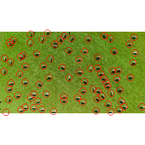

```r
plot_meansures(im,measurements = im4,pch=1,
               cex =2 )
```

Como podemos ver, todos os animas foram marcados. Logo, a contagem dos animais está correta.